# IODS course project

# A case study in principal component and multiple correspondence analysis

*In the following, we will use principal component and multiple correspondence analysis as dimension reduction techniques. We will explore the outputs of the analyses as interesting in their own right, instead merely as intermediaries on the way to further modeling harnessing the components as its possible features. We will use openly available dataset for our exploration.*

```
## [1] "Mon Dec 11 16:32:12 2023"
```

## Load and describe the dataset

We start by reading in the dataset we label ‘’human’’. The dataset concerns country-level measurements of development for most countries in the world.

```r
library(readr)
human<-read_csv("~/Intro_to_ODS/IODS/data/human.csv")
```

We then move the country names to rownames: a neat little trick, since, rather conveniently, the countries uniquely label the observations on the rows.

```r
# Move the country names to rownames
library(tibble)
human_ <- column_to_rownames(human, "Country")
```

Let us explore the data, by summarizing and visualizing it. We first look at the unidimensional summaries and kernel densities.

```r
library(tidyr)
library(ggplot2)
library(dplyr)

# Let us have the GNI per capita in thousands of dollars to avoid clutter in visuals
human_$GNI<-human_$GNI/1000

summary(human_)
```

```
##     Edu2.FM          Labo.FM          Edu.Exp         Life.Exp
##  Min.   :0.1717   Min.   :0.1857   Min.   : 5.40   Min.   :49.00
##  1st Qu.:0.7264   1st Qu.:0.5984   1st Qu.:11.25   1st Qu.:66.30
##  Median :0.9375   Median :0.7535   Median :13.50   Median :74.20
##  Mean   :0.8529   Mean   :0.7074   Mean   :13.18   Mean   :71.65
##  3rd Qu.:0.9968   3rd Qu.:0.8535   3rd Qu.:15.20   3rd Qu.:77.25
##  Max.   :1.4967   Max.   :1.0380   Max.   :20.20   Max.   :83.50
##       GNI             Mat.Mor         Ado.Birth         Parli.F
##  Min.   :  0.581   Min.   :   1.0   Min.   :  0.60   Min.   : 0.00
##  1st Qu.:  4.197   1st Qu.:  11.5   1st Qu.: 12.65   1st Qu.:12.40
##  Median : 12.040   Median :  49.0   Median : 33.60   Median :19.30
##  Mean   : 17.628   Mean   : 149.1   Mean   : 47.16   Mean   :20.91
##  3rd Qu.: 24.512   3rd Qu.: 190.0   3rd Qu.: 71.95   3rd Qu.:27.95
##  Max.   :123.124   Max.   :1100.0   Max.   :204.80   Max.   :57.50
```

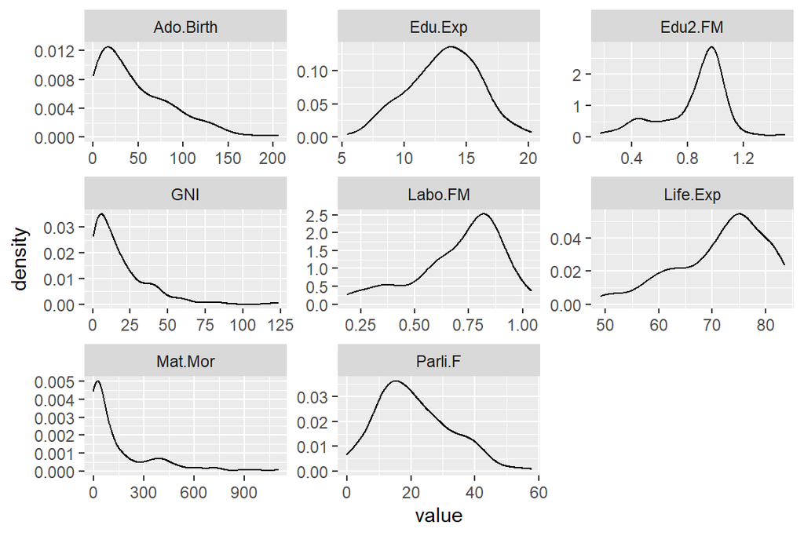

```r
# draw a kernel plot of each variable
gather(human_) %>% ggplot(aes(value)) + geom_density() + facet_wrap("key", scales = "free")
```

There are large differences between the countries in terms of these measures of development, even today. Expected years of education range from 5 to 20; ratio of the proportion of women and men participating in the labour market from roughly 0.2 to a little over 1; the ratio of the proportion of women and men with secondary education from roughly 0.2 to 1.5; life-expectancy from 49 to 83; GNI per capita from roughly 500 to 120 000 dollars per annum; proportion of the female gender in parliament from 0 to 58%; adolescent birth rate (this is probably in permilles of female adolescents) from 0.6 to over 200 and the maternal mortality ratio from 1 to 1100 (deaths per 100 000 births).

It is clear that there are high correlations between the variables: as already brought up, they can all be interpreted to fall within the same umbrella of ‘’development’‘. They offer different perspectives on the theoretical and contested umbrella concept (what is’‘development’‘, really, and who gets to define it), of course, and it is not a necessity that the measures – even if conceptually related – would all be pairwise correlated with each other. But, all in all, even the measures on gender inequality are likely to be associated with the measures that are more squarely those of development, in such a way that a’‘more developed’’ country is likely to also score higher in gender equality.

Let us take a look at the paiwise correlations in much the same way as we did in the above for the unidimensional distributions: a summary presented in the form of the Pearson sample correlation coefficients, scatter plots, and then a visual capturing the sizes of the correlations in a communicatively efficient manner.

```r
# Access GGally
library(GGally)


# Access corrplot
library(corrplot)

# Compute the correlation matrix and visualize it with corrplot
cor(human_)
```

```
##                Edu2.FM      Labo.FM     Edu.Exp   Life.Exp         GNI
## Edu2.FM    1.000000000  0.009564039  0.59325156  0.5760299  0.43030485
## Labo.FM    0.009564039  1.000000000  0.04732183 -0.1400125 -0.02173971
## Edu.Exp    0.593251562  0.047321827  1.00000000  0.7894392  0.62433940
## Life.Exp   0.576029853 -0.140012504  0.78943917  1.0000000  0.62666411
## GNI        0.430304846 -0.021739705  0.62433940  0.6266641  1.00000000
## Mat.Mor   -0.660931770  0.240461075 -0.73570257 -0.8571684 -0.49516234
## Ado.Birth -0.529418415  0.120158862 -0.70356489 -0.7291774 -0.55656208
## Parli.F    0.078635285  0.250232608  0.20608156  0.1700863  0.08920818
##              Mat.Mor  Ado.Birth     Parli.F
## Edu2.FM   -0.6609318 -0.5294184  0.07863528
## Labo.FM    0.2404611  0.1201589  0.25023261
## Edu.Exp   -0.7357026 -0.7035649  0.20608156
## Life.Exp  -0.8571684 -0.7291774  0.17008631
## GNI       -0.4951623 -0.5565621  0.08920818
## Mat.Mor    1.0000000  0.7586615 -0.08944000
## Ado.Birth  0.7586615  1.0000000 -0.07087810
## Parli.F   -0.0894400 -0.0708781  1.00000000
```

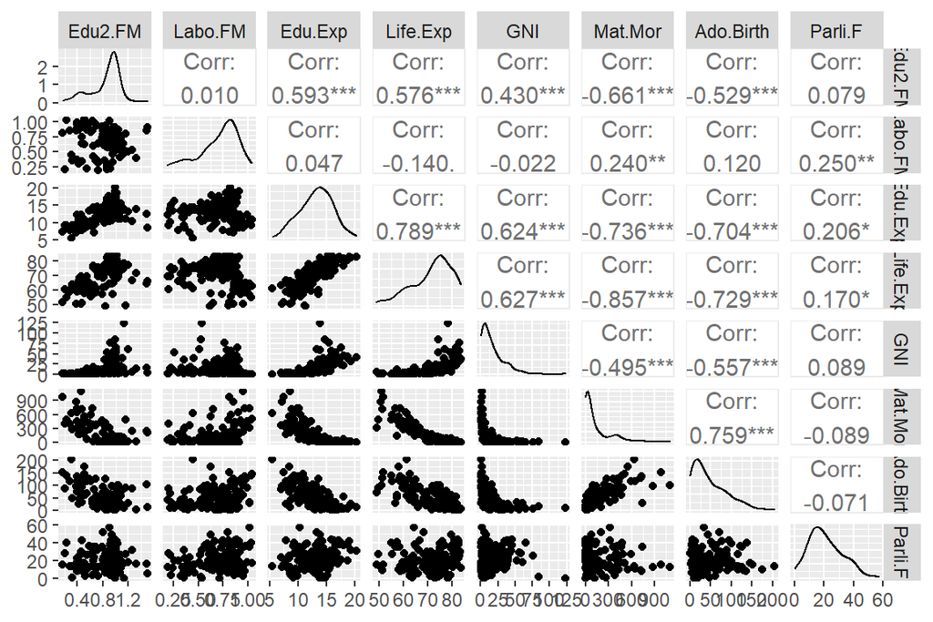

```r
# Visualize the scatter plots of the variables
ggpairs(human_, mapping = aes())
```

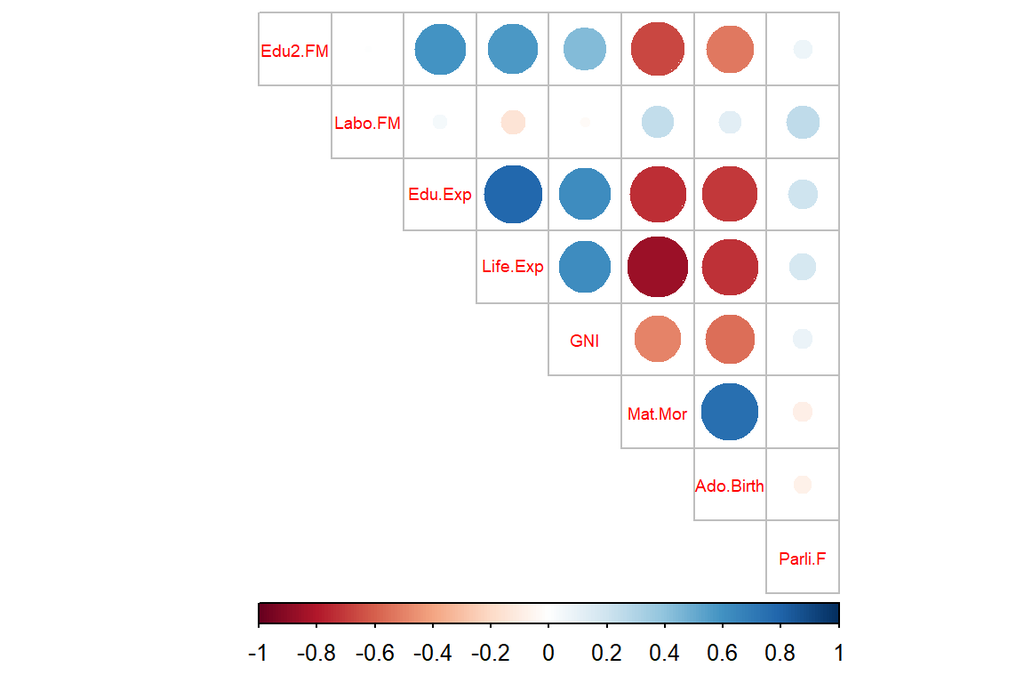

```r
# Draw the correlation plot with method circle
corrplot(cor(human_), method="circle", type="upper", cl.pos="b", tl.pos="d", tl.cex=0.6)
```

We note that some measures of inequality have numbers increasing in an ascending order with gender inequality, when this is understood as the extent to which women participate and are empowered in the society (note that there are a few countries and measures on which women are doing better than men). So when Edu2.FM increases, the proportion of women (in comparison to that of men) with secondary education increases; and the same holds for Labo.FM. The direction is the same for Parli.F (which is, unlike the two just mentioned, not a ratio of proportions but a proportion). The direction is reversed for maternal mortality and adolescent birth rate: the higher the value, the worse the situation in terms of inequality (and I guess also development, ceteris paribus).

Equipped with the understanding of the directions of the variables, and the fact that blue represents positive and red negative correlation (and the size of the circle increases with the absolute value of the correlation), we immediately notice from our visual of the correlation matrix that there are strong correlations in just the directions we hypothesized there to be: the measures that have values increasing along the level of development (GNI, life expectancy, expected years of education, proportion of women relative to men having secondary education) are positively correlated with each other, and negatively correlated with the values that have the opposite direction (adolescent births and maternal mortality) relative to the level of development. Adolescent births and maternal mortality are also highly positively correlated with each other.

However, what is most striking is that while in terms of all those variables mentioned in the previous paragraph, the Pearson correlation coefficients are remarkably high, with an absolute value almost unflinchingly above 0.4, women’s participation at the labour market and at the parliament have surprisingly low correlations with the other measures of development. What first comes to mind as a potential explanation for the surprise are some of the richer Arab countries, which probably have a very ‘’low’’ score on these two measures of gender equality, while a high score on the rest (but how about education then?). One should probe more closely into the data to find out (conveniently we have just deleted what appear to have been aggregate measures on regions such as the Arab countries).

Let us see what principal component analysis has to say about this. Principal component analysis is a dimension reduction technique that, when used as a tool for deriving composite predictors capturing the predictive import of the original dataset, could be thought of as a formalization of the following heuristic: construct a linear transformation of the original variables in such a way that captures as much as possible of the variability in the dataset; repeat, but with a linear transformation that is uncorrelated to the previous; stop when satisfied with the count of the components and their ability to capture the information of use in the dataset. In high-dimensional settings, PCA can be useful for many things: understanding variability in the dataset in a simplified form; visualizing multidimensional variability on but two or three dimensions the human mind is capable of visuall comprehending; reducing dimensions for further explanatory or predictive modeling.

We fit our PCA with the stats-package using the singular value decomposition method in the function prcomp. We plot the two first principal components (those capturing the most variability of the dataset) as a biplot. We start by utilizing our human dataset *without standardizing it*, so that our principal components are derived from the covariance instead the correlation matrix. In this case, the scales on which the variables are measured might have quite the big impact on the results, especially if there exists such a variable whose variance dominates the rest in its non-standardized scale. This variable might then appear to explain most of the multidimensional covariance, in which case we would likely have effectively failed to reach the objective of our dimension reduction, since we would have pretty much discarded the variability in the rest of our variables. For comparability with the results from our peers, we rescale our GNI variable to its original scale.

[output not shown]

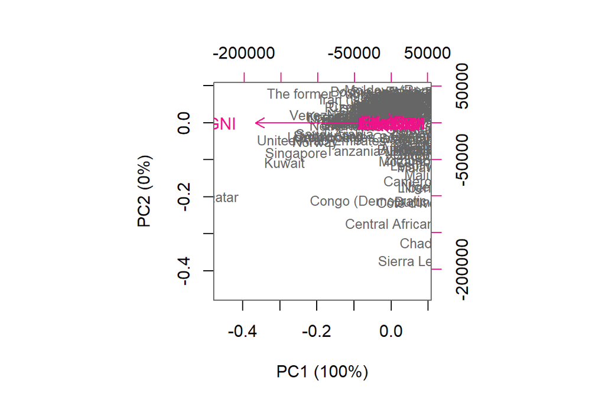

```r
# Rescale GNI to original scale
human_$GNI<-human_$GNI*1000

# Perform principal component analysis (with the SVD method)
pca_human_ <- prcomp(human_)

# Create and print out a summary of pca_human
s <- summary(pca_human_)

# Rounded percentanges of variance captured by each PC
pca_pr <- round(1*s$importance[2, ], digits = 5)

# Print out the percentages of variance
pca_pr <-round(100*pca_pr,digits=1)

# Create object pc_lab to be used as axis labels
pc_lab<-paste0(names(pca_pr), " (", pca_pr, "%)")

# Draw a biplot
biplot(pca_human_, cex = c(0.8, 1), col = c("grey40", "deeppink2"), xlab = pc_lab[1], ylab = pc_lab[2])
```

Basically we have just the case we speculated in the above, and which we also foresaw to probably end up concerning GNI, for which reason we rescaled it to its original scale. In short, GNI is what drives the multdimensional variability in the non-standardized scale, but this is not a conceptually meaningful analysis, but a happenstance of a sort, created by the differences in the natural scales of the variables. These differences in the scales result in the output of the non-standardized principal component analysis being determined by what variable ‘’happens to have’’ a scale with large variance. Although there of course are cases where one wants to conduct the analysis in the original scales, that carry the ‘’natural interpretation’’ of the variable, it is usually advisable to standardize, so that the differences in the measurements are interpreted in a manner that accounts for the differences of the scales. Ultimately this comes down to evaluating how big is a big difference in the problem context. With our dataset, with measurements of quite the motley bunch with largely varying natural scales, it does not make much sense to reduce dimensionality without standardizing. For instance, a difference in the GNI of two countries, denote this $x_{2,GNI}-x_{1,GNI}$, is *not large*, nor conceptually meaningful, in comparison to the difference in the maternal mortality of two countries, denote this $x_{2,MAT}-x_{1,MAT}$, just because $x_{2,GNI}-x_{1,GNI}>>x_{2,MAT}-x_{1,MAT}$. For we might then interpret that a difference between two countries of 400 dollars per annum in their GNI is *much larger* in comparison to their difference of 200 deaths per 100 000 births. Instead, at least for our present purposes, it is much more meaningful to interpret the difference *after accounting for the differences in the scales* and standardize so that the former difference is roughly 0.02 standard deviations and the latter 1 standard deviation. We would thereby be led to conclude that the difference between the maternal mortality ratios of the two countries is in effect much larger than the difference between their GNIs.

By printing the summary of the principal components we get the numbers for what we have visually depicted in the above: the first principal component - dominated by GNI - captures almost all of the variability in the entire dataset, with pretty much nothing left for the remaining components (and ergo we get a warning message of ‘’zero length arrow’’).

```r
summary(pca_human_)
```

```
## Importance of components:
##                              PC1      PC2   PC3   PC4   PC5   PC6    PC7    PC8
## Standard deviation     1.854e+04 185.5219 25.19 11.45 3.766 1.566 0.1912 0.1591
## Proportion of Variance 9.999e-01   0.0001  0.00  0.00 0.000 0.000 0.0000 0.0000
## Cumulative Proportion  9.999e-01   1.0000  1.00  1.00 1.000 1.000 1.0000 1.0000
```

By printing out and looking at the component loadings we see that the first principal component is but a reflection of the GNI: all other loadings are practically zero, where as that of GNI is practically -1.

```r
pca_human_$rotation
```

```
##                     PC1           PC2           PC3           PC4           PC5
## Edu2.FM   -5.607472e-06  0.0006713951 -3.412027e-05 -2.736326e-04 -0.0022935252
## Labo.FM    2.331945e-07 -0.0002819357  5.302884e-04 -4.692578e-03  0.0022190154
## Edu.Exp   -9.562910e-05  0.0075529759  1.427664e-02 -3.313505e-02  0.1431180282
## Life.Exp  -2.815823e-04  0.0283150248  1.294971e-02 -6.752684e-02  0.9865644425
## GNI       -9.999832e-01 -0.0057723054 -5.156742e-04  4.932889e-05 -0.0001135863
## Mat.Mor    5.655734e-03 -0.9916320120  1.260302e-01 -6.100534e-03  0.0266373214
## Ado.Birth  1.233961e-03 -0.1255502723 -9.918113e-01  5.301595e-03  0.0188618600
## Parli.F   -5.526460e-05  0.0032317269 -7.398331e-03 -9.971232e-01 -0.0716401914
##                     PC6           PC7           PC8
## Edu2.FM    2.180183e-02  6.998623e-01  7.139410e-01
## Labo.FM    3.264423e-02  7.132267e-01 -7.001533e-01
## Edu.Exp    9.882477e-01 -3.826887e-02  7.776451e-03
## Life.Exp  -1.453515e-01  5.380452e-03  2.281723e-03
## GNI       -2.711698e-05 -8.075191e-07 -1.176762e-06
## Mat.Mor    1.695203e-03  1.355518e-04  8.371934e-04
## Ado.Birth  1.273198e-02 -8.641234e-05 -1.707885e-04
## Parli.F   -2.309896e-02 -2.642548e-03  2.680113e-03
```

So it is clear that our results our meaningless, unless we standardize our variables. So let us do just that and see what impact this has on our results.

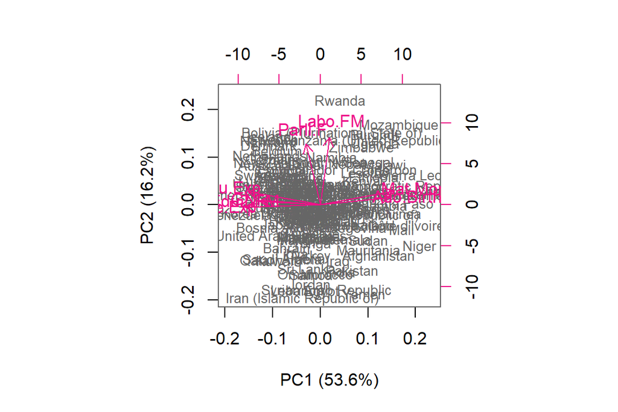

```r
# Standardize the human dataset
human_std <- as.data.frame(scale(human_))

# Perform principal component analysis (with the SVD method)
pca_human_std <- prcomp(human_std)

# Save the summary for plotting purposes
s_std<-summary(pca_human_std)

# Rounded percentanges of variance captured by each PC
pca_pr <- round(1*s_std$importance[2, ], digits = 5)

# Print out the percentages of variance
pca_pr <-round(100*pca_pr,digits=1)

# Create object pc_lab to be used as axis labels
pc_lab<-paste0(names(pca_pr), " (", pca_pr, "%)")

# Draw a biplot
biplot(pca_human_std, cex = c(0.8, 1), col = c("grey40", "deeppink2"), xlab = pc_lab[1], ylab = pc_lab[2])
```

This has the general appearance we expect, but there are so many countries that their names tend to hide the arrows depicting the relationships between our variables and our components. So let us make these names a bit smaller (a better alternative might be to plot but a sample of the names). Also, the names of the variables are too large, so we reduce their size as well.

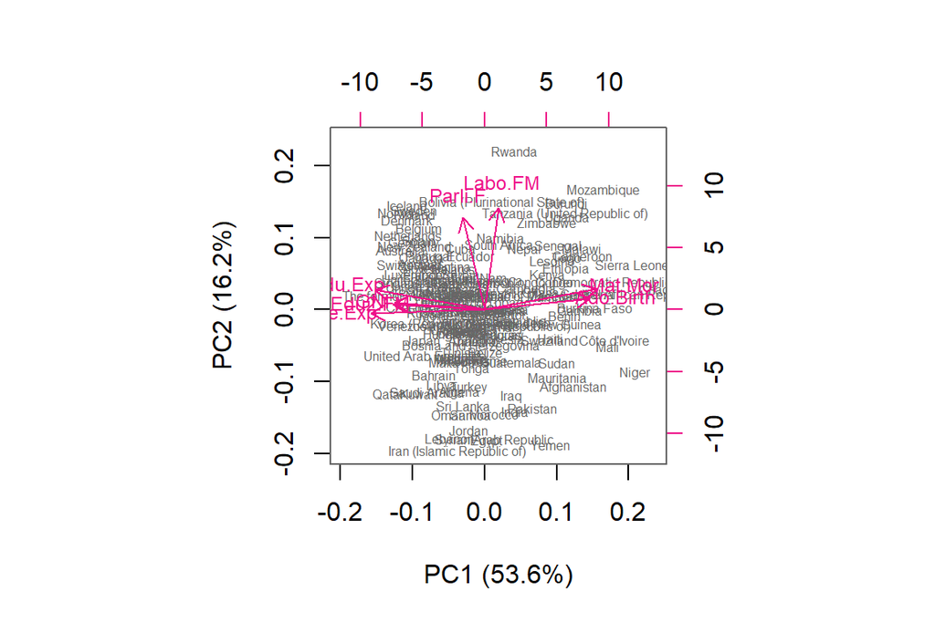

```r
# Draw a biplot
biplot(pca_human_std, cex = c(0.5, 0.75), col = c("grey40", "deeppink2"), xlab = pc_lab[1], ylab = pc_lab[2])
```

We observe that roughly 54% of the variance is captured by our first principal component (on the x-axis), and 16% by our second component (on the y-axis). We may readily observe from the plot that it depicts the correlation structure we verbally described earlier rather well. What we have is the first principal component comprised of the highly correlated indicators of development, so that those variables with different direction have opposite signs. High maternal mortality and adolescent birth is associated with lower development levels overall; whereas the opposite holds for higher expected life-years, longer education, higher gross national income and a higher proportion of women with secondary education (relative to the similar proportion of men). We then have the second component mostly made up of the proportion of women that participate in the labour market (as opposed to the similar proportion of men) and the representation of the female gender in the parliament. This is aligned with what we found earlier: that these two variables are pretty much uncorrelated with the rest.

We may print out the component loadings to observe the numbers behind the structure we have verbally described in the above. We note that the two components are indeed rather neatly distinguished by these two sets of variables: the loadings are low on the first component in terms of the variables dominating the second component (Labo.FM and Parli.F), and vice versa. We note that together the first two components explain only 70% of the variance: thus the third component is also of interest (in fact, each additional component from 3 to 6 are accompanied by a rather constant added value in terms of the percentage points of variance explained, so that the third component adds roughly 10, the fourth 8, the fifth 5 and the sixth 4 percentage points). As the second, the third component reflects most the Labo.FM and the Parli.F variables, but with the former of the opposite sign than in the second component. In fact, almost all of the other variables besides Parli.F have loadings with opposite terms to those they have on the second component. The absolute values of the loadings of these variables also tend to be higher on the third than the the second component. The fourth component mostly reflect the variables Edu2.FM and GNI.

```r
# Print summary
s_std
```

```
## Importance of components:
##                           PC1    PC2     PC3     PC4     PC5     PC6     PC7
## Standard deviation     2.0708 1.1397 0.87505 0.77886 0.66196 0.53631 0.45900
## Proportion of Variance 0.5361 0.1624 0.09571 0.07583 0.05477 0.03595 0.02634
## Cumulative Proportion  0.5361 0.6984 0.79413 0.86996 0.92473 0.96069 0.98702
##                            PC8
## Standard deviation     0.32224
## Proportion of Variance 0.01298
## Cumulative Proportion  1.00000
```

```r
# Print loadings
s_std$rotation
```

```
##                   PC1         PC2         PC3         PC4        PC5
## Edu2.FM   -0.35664370  0.03796058 -0.24223089  0.62678110 -0.5983585
## Labo.FM    0.05457785  0.72432726 -0.58428770  0.06199424  0.2625067
## Edu.Exp   -0.42766720  0.13940571 -0.07340270 -0.07020294  0.1659678
## Life.Exp  -0.44372240 -0.02530473  0.10991305 -0.05834819  0.1628935
## GNI       -0.35048295  0.05060876 -0.20168779 -0.72727675 -0.4950306
## Mat.Mor    0.43697098  0.14508727 -0.12522539 -0.25170614 -0.1800657
## Ado.Birth  0.41126010  0.07708468  0.01968243  0.04986763 -0.4672068
## Parli.F   -0.08438558  0.65136866  0.72506309  0.01396293 -0.1523699
##                   PC6         PC7         PC8
## Edu2.FM    0.17713316  0.05773644  0.16459453
## Labo.FM   -0.03500707 -0.22729927 -0.07304568
## Edu.Exp   -0.38606919  0.77962966 -0.05415984
## Life.Exp  -0.42242796 -0.43406432  0.62737008
## GNI        0.11120305 -0.13711838 -0.16961173
## Mat.Mor    0.17370039  0.35380306  0.72193946
## Ado.Birth -0.76056557 -0.06897064 -0.14335186
## Parli.F    0.13749772  0.00568387 -0.02306476
```

The loadings of the first two components are perhaps best interpreted from the biplot and the names of the countries that are distinguished by their first two component values.

Here we do in fact observe pretty much what we speculated earlier as explanatory of the surprisingly low correlation between the other indicators of development (and gender inequality, if this is not considered within the umbralle of ‘’development’’) and female participation in the labour market and in the parliament. It is mostly the Arab countries that stand out as a group of their own in the south-west corner of our area mapped by the coordinates of our first two principal components. In the southeast quadrant we have relatively few countries that are characterized by low representation of the female gender at both the labor market and in politics, accompanied by a low level of development in terms of education, life-expectancy, income, maternal mortality and adolescent births. In the northeast quadrant, we have the countries with high levels of participation of the female gender at the labor market and in the parliament, but a low-level of development otherwise. Finally, in the northwest quadrant we have the developed countries with high levels of gender equality, with those furthest away from the origo on that diagonal the Nordic countries along other Western, highly-developed liberal democracies (such as Belgium).

Let us add captions to the plot to indicate the interpretations we have provided for our quadrants in terms of our first two principal components. We use the package AMR, since this allows us to neatly handle the biplot as a ggplot object, which will then also help us create a more pleasing outlook. The downside is that the principal components are standardized by default, and it appears this cannot be changed, so we have a minor inconvenience with the mismatch of the axis-values with those of our previous biplots.

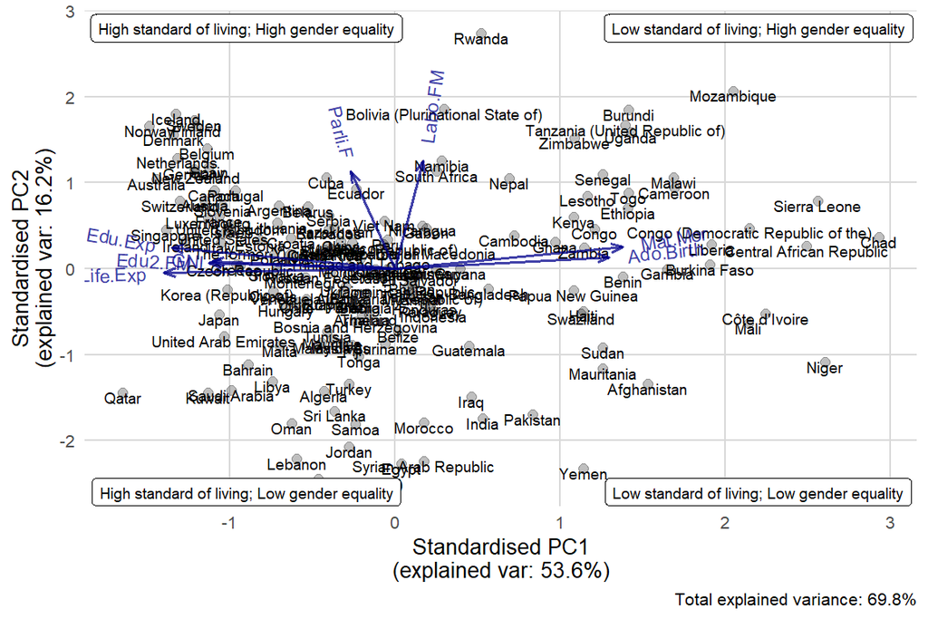

```r
# We require the AMR library for handling the biplot as ggplot object (or "devtools")
library(AMR)

biplot<-ggplot_pca(pca_human_std, labels=rownames(pca_human_std$x),labels_textsize=2.5,
                   arrows_textsize=3,arrows_size=0.7)
biplot + geom_label(label="High standard of living; High gender equality", x=-0.9, y=2.8, size=2.5) + geom_label(label="Low standard of living; High gender equality",, x=2.2, y=2.8, size=2.5) + geom_label(label="High standard of living; Low gender equality",, x=-0.9, y=-2.6, size=2.5) + geom_label(label="Low standard of living; Low gender equality",, x=2.2, y=-2.6, size=2.5)
```

The plot is now a little more readable than our earlier biplot, and we have the interpretations for the quadrants in the labels. Another alternative to communicate a similar point would have been to colour the groups of observations by their coordinates. We have cut some corners in aiming to capture the sense of the variables determining the principal components by labeling the first component one concerning ‘’standard of living’’ and the other ‘’gender equality’‘. The former label is somewhat too narrow of a term, but it is better than, say,’‘economic development’’ and many other variants I can think of that have too heavy of an emphasis on material well being. The latter label – gender equality – is, on the contrary, too broad. For we have here only participation in the labour market and representation in the parliament. For instance, gender equal education is in reflected more heavily on the first principal component.

For our final bit of this case study, we turn to multiple correspondence analysis, which can be considered family resemblant with principal component analysis in the sense that it can be used to serve pretty much the same tasks, but on categorical rather than interval-valued data.

We first load in the dataset that concerns tea consumption: habits, impressions, likes and dislikes of its consumers. We turn strings into factors when loading in the data.

```r
library(readr)
tea <- read.csv("https://raw.githubusercontent.com/KimmoVehkalahti/Helsinki-Open-Data-Science/master/datasets/tea.csv", stringsAsFactors = TRUE)
```

```r
# Take a look at the dimensions of the dataset
dim(tea)
```

```
## [1] 300  36
```

```r
# Take a look at the structure of the dataset
str(tea)
```

```
## 'data.frame':    300 obs. of  36 variables:
##  $ breakfast       : Factor w/ 2 levels "breakfast","Not.breakfast": 1 1 2 2 1 2 1 2 1 1 ...
##  $ tea.time        : Factor w/ 2 levels "Not.tea time",..: 1 1 2 1 1 1 2 2 2 1 ...
##  $ evening         : Factor w/ 2 levels "evening","Not.evening": 2 2 1 2 1 2 2 1 2 1 ...
##  $ lunch           : Factor w/ 2 levels "lunch","Not.lunch": 2 2 2 2 2 2 2 2 2 2 ...
##  $ dinner          : Factor w/ 2 levels "dinner","Not.dinner": 2 2 1 1 2 1 2 2 2 2 ...
##  $ always          : Factor w/ 2 levels "always","Not.always": 2 2 2 2 1 2 2 2 2 2 ...
##  $ home            : Factor w/ 2 levels "home","Not.home": 1 1 1 1 1 1 1 1 1 1 ...
##  $ work            : Factor w/ 2 levels "Not.work","work": 1 1 2 1 1 1 1 1 1 1 ...
##  $ tearoom         : Factor w/ 2 levels "Not.tearoom",..: 1 1 1 1 1 1 1 1 1 2 ...
##  $ friends         : Factor w/ 2 levels "friends","Not.friends": 2 2 1 2 2 2 1 2 2 2 ...
##  $ resto           : Factor w/ 2 levels "Not.resto","resto": 1 1 2 1 1 1 1 1 1 1 ...
##  $ pub             : Factor w/ 2 levels "Not.pub","pub": 1 1 1 1 1 1 1 1 1 1 ...
##  $ Tea             : Factor w/ 3 levels "black","Earl Grey",..: 1 1 2 2 2 2 2 1 2 1 ...
##  $ How             : Factor w/ 4 levels "alone","lemon",..: 1 3 1 1 1 1 1 3 3 1 ...
```

[output cut: 22 more lines]

We have 300 observations of 36 variables, with all but ‘’age’’ categorical. The values are responses of tea consumers on questions relating to their tea-drinking, and their perceptions thereon. We have a broad range of variables on when the respondent consumes tea, where, with whom, in what occasions, how, what type of tea, and what are his impressions of tea, his motives for drinking it and so on. We also have some basic questions on the respondents’ background, such as their age, gender and apparently also on their socioeconomic class in terms of their profession. All in all, we have quite the rich tea dataset, even if one wonders whether the tea-loving respondent has been unduly strained when forced to choose but one category for each question (breakfast, not-breakfast!). Or, perhaps such strict compartmentalization is not a strain, but a pleasure for the tea enthusiast.

There are, of course, a little too many variables to summarize, so we pick a small subset of six variables to take a closer look at. We visualize their unidimensional distributions by barplots that are befitting for the measurement level of our chosen variables that are all factors.

```r
library(dplyr)
library(tidyr)

# Enlist column names to keep in the dataset
keep_columns <- c("Tea", "How", "how", "sugar", "where", "lunch")

# Select the 'keep_columns' to create a new dataset
tea_time <- dplyr::select(tea, all_of(keep_columns))

# look at the summaries and structure of the data
summary(tea_time)
```

```
##         Tea         How                      how           sugar
##  black    : 74   alone:195   tea bag           :170   No.sugar:155
##  Earl Grey:193   lemon: 33   tea bag+unpackaged: 94   sugar   :145
##  green    : 33   milk : 63   unpackaged        : 36
##                  other:  9
##                   where           lunch
##  chain store         :192   lunch    : 44
##  chain store+tea shop: 78   Not.lunch:256
##  tea shop            : 30
##
```

```r
str(tea_time)
```

```
## 'data.frame':    300 obs. of  6 variables:
##  $ Tea  : Factor w/ 3 levels "black","Earl Grey",..: 1 1 2 2 2 2 2 1 2 1 ...
##  $ How  : Factor w/ 4 levels "alone","lemon",..: 1 3 1 1 1 1 1 3 3 1 ...
##  $ how  : Factor w/ 3 levels "tea bag","tea bag+unpackaged",..: 1 1 1 1 1 1 1 1 2 2 ...
##  $ sugar: Factor w/ 2 levels "No.sugar","sugar": 2 1 1 2 1 1 1 1 1 1 ...
##  $ where: Factor w/ 3 levels "chain store",..: 1 1 1 1 1 1 1 1 2 2 ...
##  $ lunch: Factor w/ 2 levels "lunch","Not.lunch": 2 2 2 2 2 2 2 2 2 2 ...
```

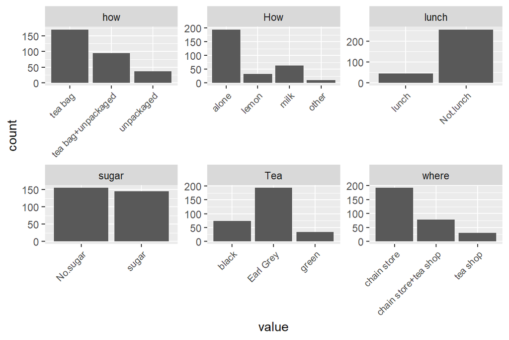

```r
# visualize the dataset
library(ggplot2)
pivot_longer(tea_time, cols = everything()) %>%
  ggplot(aes(value)) + geom_bar() + facet_wrap("name", scales = "free") + theme(axis.text.x = element_text(angle = 45, hjust = 1, size = 8))
```

```r
sum(is.na(tea_time))
```

```
## [1] 0
```

We have a dataset of our chosen six variables with 300 observations and no missing values. It seems the majority of the respondents drink their tea *with a teabag* (principle of least effort!), *without lemon* or milk or any other addendums, *not at lunch time*, without sugar (although there is practically a tie here), as *Earl Grey* that is bought from the *chain store*. Note that these summaries are based on the univariate distributions: it might be that the conjunction of the above sets is an exception class (although I doubt this to be the case), even if they were, separately, the majority classes.

As with principal component analysis, multiple correspondence analysis proves useful in visually summarizing multidimensional (categorical) data. For even though we could merely print the pairwise contingency tables, such as:

```r
table(tea_time$how,tea_time$where)
```

```
##
##                      chain store chain store+tea shop tea shop
##   tea bag                    146                   19        5
##   tea bag+unpackaged          37                   51        6
##   unpackaged                   9                    8       19
```

to observe, for instance, that if we knew that one used unpackaged tea, we would also know him to be much, much more likely to buy their tea from the tea shop (than someone who uses tea bags), we would run into difficulties in the higher dimensions (while we could still manage three dimensions – since we could just partition contingency tables such as the one in the above by an additional factor – a fourth dimension would have us stumble).

So let us look at a visual constructed in line with multiple correspondence analysis of the MAC function in the FactoMineR package.

```r
# Tea_time is available

# Multiple correspondence analysis
library(FactoMineR)
```

```r
mca <- MCA(tea_time, graph = FALSE)

# summary of the model
summary(mca)
```

```
##
## Call:
## MCA(X = tea_time, graph = FALSE)
##
##
## Eigenvalues
##                        Dim.1   Dim.2   Dim.3   Dim.4   Dim.5   Dim.6   Dim.7
## Variance               0.279   0.261   0.219   0.189   0.177   0.156   0.144
## % of var.             15.238  14.232  11.964  10.333   9.667   8.519   7.841
## Cumulative % of var.  15.238  29.471  41.435  51.768  61.434  69.953  77.794
##                        Dim.8   Dim.9  Dim.10  Dim.11
## Variance               0.141   0.117   0.087   0.062
## % of var.              7.705   6.392   4.724   3.385
## Cumulative % of var.  85.500  91.891  96.615 100.000
##
## Individuals (the 10 first)
##                       Dim.1    ctr   cos2    Dim.2    ctr   cos2    Dim.3
## 1                  | -0.298  0.106  0.086 | -0.328  0.137  0.105 | -0.327
## 2                  | -0.237  0.067  0.036 | -0.136  0.024  0.012 | -0.695
## 3                  | -0.369  0.162  0.231 | -0.300  0.115  0.153 | -0.202
## 4                  | -0.530  0.335  0.460 | -0.318  0.129  0.166 |  0.211
## 5                  | -0.369  0.162  0.231 | -0.300  0.115  0.153 | -0.202
## 6                  | -0.369  0.162  0.231 | -0.300  0.115  0.153 | -0.202
## 7                  | -0.369  0.162  0.231 | -0.300  0.115  0.153 | -0.202
## 8                  | -0.237  0.067  0.036 | -0.136  0.024  0.012 | -0.695
## 9                  |  0.143  0.024  0.012 |  0.871  0.969  0.435 | -0.067
## 10                 |  0.476  0.271  0.140 |  0.687  0.604  0.291 | -0.650
##                       ctr   cos2
## 1                   0.163  0.104 |
## 2                   0.735  0.314 |
## 3                   0.062  0.069 |
## 4                   0.068  0.073 |
## 5                   0.062  0.069 |
## 6                   0.062  0.069 |
## 7                   0.062  0.069 |
## 8                   0.735  0.314 |
## 9                   0.007  0.003 |
## 10                  0.643  0.261 |
##
## Categories (the 10 first)
```

[output cut: 16 more lines]

```
## lemon                3.226 |   1.329  14.771   0.218   8.081 |
## milk                 2.422 |   0.013   0.003   0.000   0.116 |
## other                5.534 |  -2.524  14.526   0.197  -7.676 |
## tea bag             -6.941 |  -0.065   0.183   0.006  -1.287 |
## tea bag+unpackaged  11.956 |   0.019   0.009   0.000   0.226 |
## unpackaged          -6.482 |   0.257   0.602   0.009   1.640 |
##
## Categorical variables (eta2)
##                      Dim.1 Dim.2 Dim.3
## Tea                | 0.126 0.108 0.410 |
## How                | 0.076 0.190 0.394 |
## how                | 0.708 0.522 0.010 |
## sugar              | 0.065 0.001 0.336 |
## where              | 0.702 0.681 0.055 |
## lunch              | 0.000 0.064 0.111 |
```

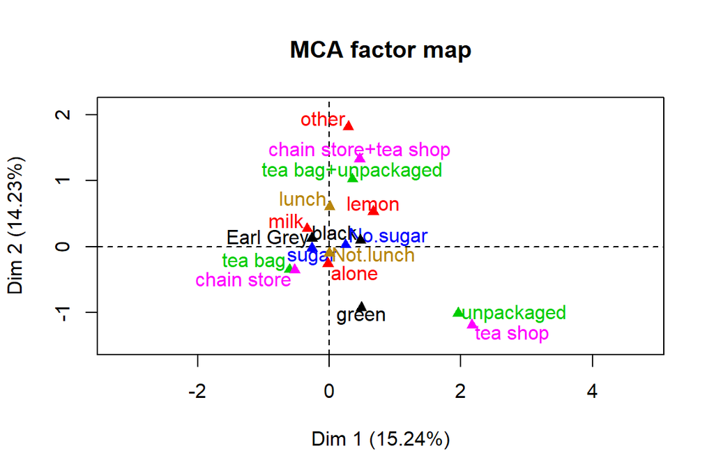

```r
# visualize MCA
plot(mca, invisible=c("ind"),graph.type = "classic",habillage = "quali")
```

It appears that those that like their tea unpackaged from the teashop, are also more likely to prefer to have it green and not to drink it during lunch, whereas those who buy it from the chain store, are likely to drink it in a bag, alone or with sugar. Those that are ‘’in between’’ in terms of where they get their tea (both from the chain store and from the tea shop) are also more likely to be ‘’in between’’ in terms of how they like their tea: either with tea bag or unpackaged. These people are also slighly more likely to enjoy their tea at lunch time, with lemon and milk.

So we have three groups, which could perhaps be labelled ‘’the tea snobs’‘,’‘the ’everyday’ tea consumers’’ and the ‘’in-betweens’’, in the respective order to the introduction of the defining characteristics of the groups in the previous paragraph.

# A case study in longitudinal data analysis

*Longitudinal data concern multiple measurements on usually the same statistical unit, with the measurements taken at different points in time. This creates a correlation structure within-the-unit (or whatever it is that is shared across time), so that the repeated measurements on the same unit cannot be, by default, considered independent of one another. On top of this need of accounting for the hierarchical structure of the data, longitudinal analysis is often concerned with the intensity with which the measurement values change in one or another direction per some time interval. In the following, we will concentrate solely on the effect that the former characteristics ought to have on our data analysis. We will account for the hierarchical nature of the data by utilizing random and mixed effects linear models.*

```
## [1] "Mon Dec 11 16:32:22 2023"
```

## Part 1: the RATS data

Let us first take a look at the repeated measurements on the weights of the rats so that we have the growth curves plotted for each rat, but in such a way that the linetype for each curve is determined by the diet of the rat.

```r
# Require readr and load the dataset
library(readr)
RATSL<-read_csv("~/Intro_to_ODS/IODS/data/RATSL.csv")
```

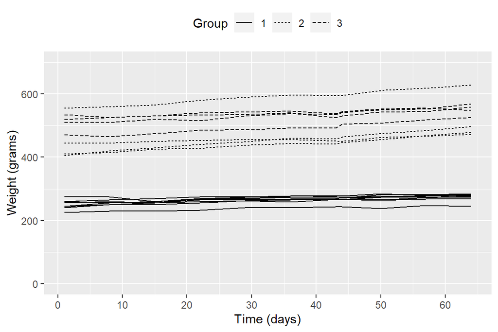

```r
# Turn ID and group into factors
RATSL$ID<-as.factor(RATSL$ID)
RATSL$Group<-as.factor(RATSL$Group)

# Require ggplot2
library(ggplot2)

# Draw the plot
ggplot(RATSL, aes(x = Time, y = Weight, group = ID)) +
  geom_line(aes(linetype = Group)) +
  scale_x_continuous(name = "Time (days)", breaks = seq(0, 60, 10)) +
  scale_y_continuous(name = "Weight (grams)", limits=c(0,700)) +
  theme(legend.position = "top")
```

We may observe that we have slopes for the growth curves that appear pretty much linear through time, and the slopes all appear consistent and positive, so that the weight increases by a pretty much constant amount per unit of time throughout the time interval and *within subject*. Furthermore, all slopes have pretty similar values across the time interval. It appear that, perhaps, in absolute terms, group 1 has a lower weight increase than groups 2 and 3, *but the groups are not balanced at baseline*: group 1 comprises clearly of rats that are much leaner than those in groups 2 and 3. So that it might be the case that percent-wise the increase in weight is of the same magnitude in group 1 as in the other two. Not only is group 1 on average lighter at baseline, it also appears less variable. Further, was it not for a single individual with the highest weight through time, all individuals of group 2 would be heavier than all indvididuals in group 1 and lighter than all individuals in group 3. What’s more, it appears that there is very little criss-crossing of the growth curves: the ranks in terms of the weights remain pretty much constant through time. This seems a well-behaved dataset to the point of artificiality.

There is no need to standardize the data by day, to make the above observations, since the slopes are so consistent that standardising with respect to the daily subset of weights would have little to no effect on the plots. However, for the sake of it, let’s just verify that this is indeed so.

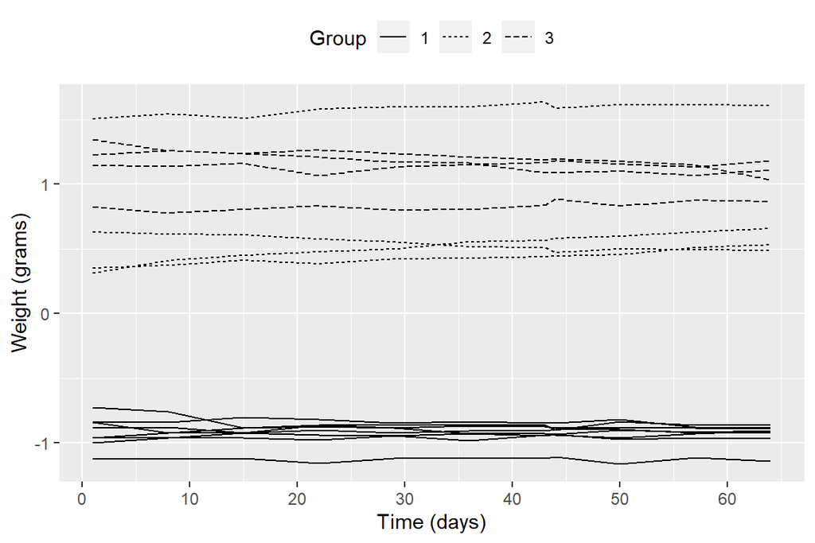

```r
# Standardise the variable weigth and plot again.
library(dplyr)

RATSL <- RATSL %>%
  group_by(Time) %>%
  mutate(stdWeight = scale(Weight)) %>%
  ungroup()

ggplot(RATSL, aes(x = Time, y = stdWeight, group = ID)) +
  geom_line(aes(linetype = Group)) +
  scale_x_continuous(name = "Time (days)", breaks = seq(0, 60, 10)) +
  scale_y_continuous(name = "Weight (grams)") +
  theme(legend.position = "top")
```

Indeed, this is pretty much the same figure as our earlier one, with only the scale of the y-axis having changed.

Now we could lump all rats within each diet into one, so that we would discard individual differences in the growth curves. Since there are no missing values in our repeated measurements, we could simply estimate the average weight of each rat by the day based on the average of that group of rats on that day; the standard error of the estimate by the standard error of the diet-specific mean. Let us do so and plot the results.

```r
library(dplyr)
library(tidyr
        )
# Summarize the data with mean and standard error of weight by group and day
# Here we will have the n for the formula of standard error of the mean to vary
# by non missing values of weight grouped by diet and day
RATSS <- RATSL %>%
  group_by(Group, Time) %>%
  summarise( mean = mean(Weight), se = sd(Weight)/sqrt(sum(!is.na(Weight))) ) %>%
  ungroup()
# Glimpse the data
glimpse(RATSS)
```

```
## Rows: 33
## Columns: 4
## $ Group <fct> 1, 1, 1, 1, 1, 1, 1, 1, 1, 1, 1, 2, 2, 2, 2, 2, 2, 2, 2, 2, 2, 2~
## $ Time  <dbl> 1, 8, 15, 22, 29, 36, 43, 44, 50, 57, 64, 1, 8, 15, 22, 29, 36, ~
## $ mean  <dbl> 250.625, 255.000, 254.375, 261.875, 264.625, 265.000, 267.375, 2~
## $ se    <dbl> 5.381640, 4.629100, 4.057346, 4.808614, 3.909409, 4.166190, 3.87~
```

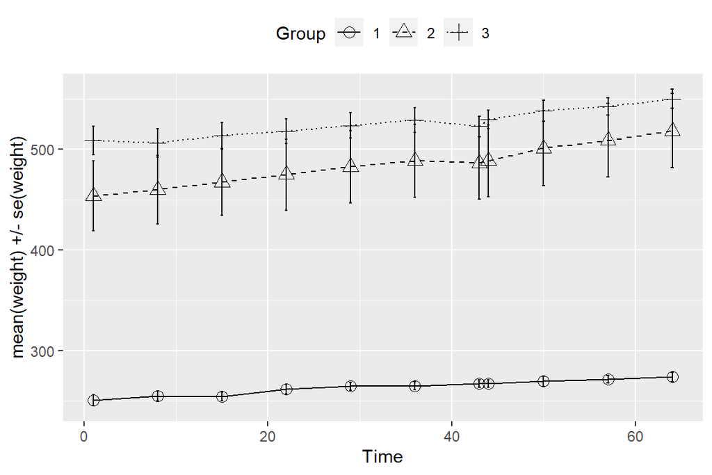

```r
# Plot the mean profiles
library(ggplot2)
ggplot(RATSS, aes(x = Time, y = mean, linetype = Group, shape = Group)) +
  geom_line() +
  scale_linetype_manual(values = c(1,2,3)) +
  geom_point(size=3) +
  scale_shape_manual(values = c(1,2,3)) +
  geom_errorbar(aes(ymin=mean-se, ymax=mean+se, linetype="1"), width=0.3) +
  theme(legend.position = "top") +
  scale_y_continuous(name = "mean(weight) +/- se(weight)")
```

In the above we have the point estimates for the group- and day-wise means, derived *as if we had distinct cross-sections of independent samples of weights from a group-wise population*. We in effect assume that the dietary group membership is all that matters for each singular daily weight. The above type of a plot is all in all pretty much useless for what we supposedly want to derive: an estimate for the effect of the diet measured as an expected *change* in the weight of the rat. Ideally we would want to be able to compare an estimated individual growth curve to what it would have been for an otherwise similar comparator rat, but one that would not have been subjected to the diet being evaluated.

Even if putting the issue of the counterfactual aside that has to do with deriving any causal estimates, we must further note, that with our dataset that is imbalanced at baseline, we cannot generalize to any future rat that is unlike those in our sample. We could not infer the expected weight of the rat for, say treatment 1, if his baseline weight were something drastically different from the baseline weights of the sample of our rats having been provided the treatment in question (say we wanted to estimate, based on our data, what a rat would weigh at sixty days, if it was provided treatment 1 and it weighed 600 grams at baseline).

So individual time-slice estimates are not really our ultimate concern, especially with the imbalance. If they were, we could infer that the rats in dietary group 1 are on average much slimmer than those in the other groups throughout the followup period, but that the standard errors of our estimates for the weights of the rats in the other two groups overlap. As the graph reads, we have plotted the point estimates for the mean weights and their error bars whose widths coincide with +- 1 standard errors.

It is clear that we do not have any genuine outliers in our dataset, so we will not work through that portion of this part of the assignment. We note, howver, that there is one rat in group three who is somewhat slimmer than the other rats in the group; just as there is one rat in group two that is somewhat heavier than the other rats in his group.

We thus proceed onwards with our simplified analysis that knowingly fails to account for the longitudinal nature of our dataset and the primary interest we have in inferring rates of change by treatment. We next discard the factor of time entirely, merely looking at the estimates for the group-wise mean weights aggregated throughout the time period of our followup.

We ignore the baseline as per standard protocol, but this really makes no difference for the results, since we have such high correlation between consecutive measurements within-rat (the weight measured at our second time point is almost entirely determined by the weight measured at our first time point). We also already know what results we are going to get from our above plots, with all the time-slice point estimates consistently ordered, in an ascending order of magnitude, by the group index.

```r
library(dplyr)
library(tidyr)

# Create a summary data by treatment and subject with mean as the summary variable (ignoring baseline week 0)
RATSLS <- RATSL %>%
  filter(Time > 1) %>%
  group_by(Group, ID) %>%
  summarise( mean=mean(Weight) ) %>%
  ungroup()
# Glimpse the data
glimpse(RATSLS)
```

```
## Rows: 16
## Columns: 3
## $ Group <fct> 1, 1, 1, 1, 1, 1, 1, 1, 2, 2, 2, 2, 3, 3, 3, 3
## $ ID    <fct> 1, 2, 3, 4, 5, 6, 7, 8, 9, 10, 11, 12, 13, 14, 15, 16
## $ mean  <dbl> 263.2, 238.9, 261.7, 267.2, 270.9, 276.2, 274.6, 267.5, 443.9, 4~
```

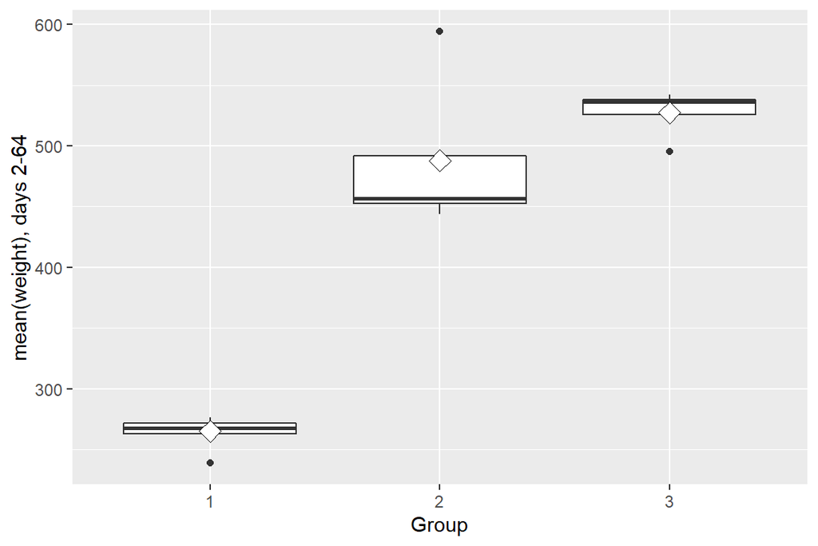

```r
# Draw a boxplot of the mean versus treatment
library(ggplot2)
ggplot(RATSLS, aes(x = Group, y = mean)) +
  geom_boxplot() +
  stat_summary(fun = "mean", geom = "point", shape=23, size=4, fill = "white") +
  scale_y_continuous(name = "mean(weight), days 2-64")
```

Even if we did not want to do a proper longitudinal analysis, it would be more meaningful to look at the within-group differences in the distributions at the start and at the end of the followup, and then compare these differences across the diets. We could summarize the distributions in the beginning and at the end by some summary, such as the mean, and then calculate the difference in terms of these summaries. Let us do just that and quickly glimpse how the differences between the groups then appear.

```r
library(dplyr)
library(tidyr)

# Create a summary data by treatment and subject with mean as the summary variable for the start of the followup
RATSLS_start <- RATSL %>%
  filter(Time < 9) %>%
  group_by(Group, ID) %>%
  summarise( mean=mean(Weight) ) %>%
  ungroup()
# Create a summary data by treatment and subject with mean as the summary variable for the start of the followup
RATSLS_end <- RATSL %>%
  filter(Time > 56) %>%
  group_by(Group, ID) %>%
  summarise( mean=mean(Weight) ) %>%
  ungroup()
# Glimpse the data
glimpse(RATSLS_start)
```

```
## Rows: 16
## Columns: 3
## $ Group <fct> 1, 1, 1, 1, 1, 1, 1, 1, 2, 2, 2, 2, 3, 3, 3, 3
## $ ID    <fct> 1, 2, 3, 4, 5, 6, 7, 8, 9, 10, 11, 12, 13, 14, 15, 16
## $ mean  <dbl> 245.0, 227.5, 247.5, 257.5, 257.5, 262.5, 275.0, 250.0, 412.5, 4~
```

```r
glimpse(RATSLS_end)
```

```
## Rows: 16
## Columns: 3
## $ Group <fct> 1, 1, 1, 1, 1, 1, 1, 1, 2, 2, 2, 2, 3, 3, 3, 3
## $ ID    <fct> 1, 2, 3, 4, 5, 6, 7, 8, 9, 10, 11, 12, 13, 14, 15, 16
## $ mean  <dbl> 275.0, 246.0, 268.5, 274.0, 279.0, 280.0, 282.5, 276.0, 473.0, 4~
```

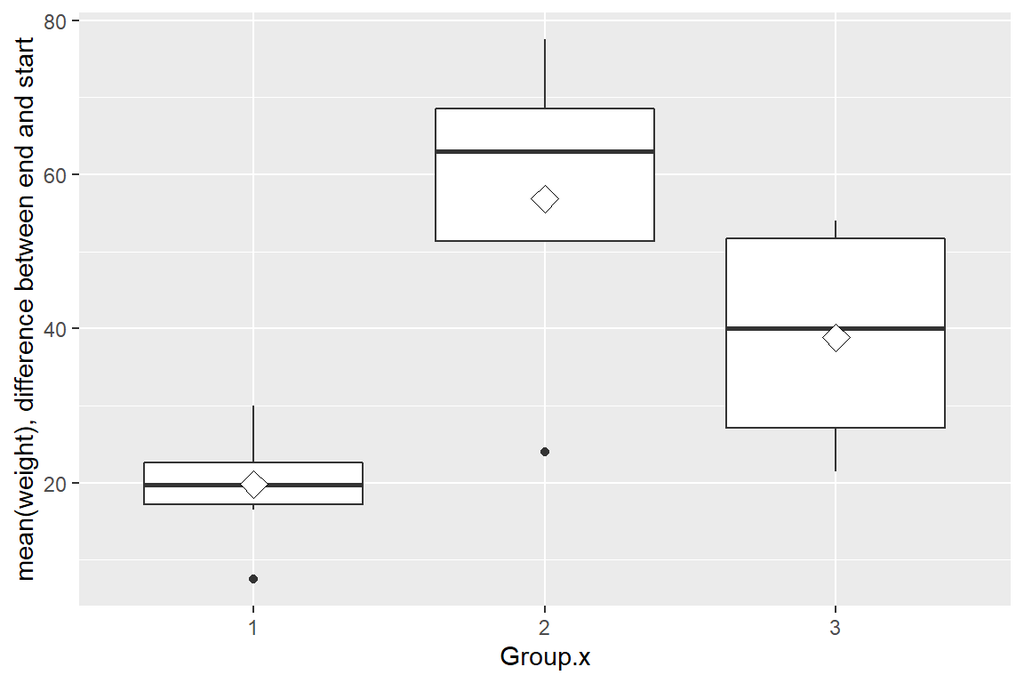

```r
# Join the datasets and remove the originals as redundant
RATSLS_change<-inner_join(RATSLS_start, RATSLS_end,by="ID")

rm(RATSLS_start)
rm(RATSLS_end)

# Calculate the difference
RATSLS_change<-mutate(RATSLS_change,difference=mean.y-mean.x)

# Draw a boxplot of the difference in means at the end and at the start by treatment
library(ggplot2)
ggplot(RATSLS_change, aes(x = Group.x, y = difference)) +
  geom_boxplot() +
  stat_summary(fun = "mean", geom = "point", shape=23, size=4, fill = "white") +
  scale_y_continuous(name = "mean(weight), difference between end and start")
```

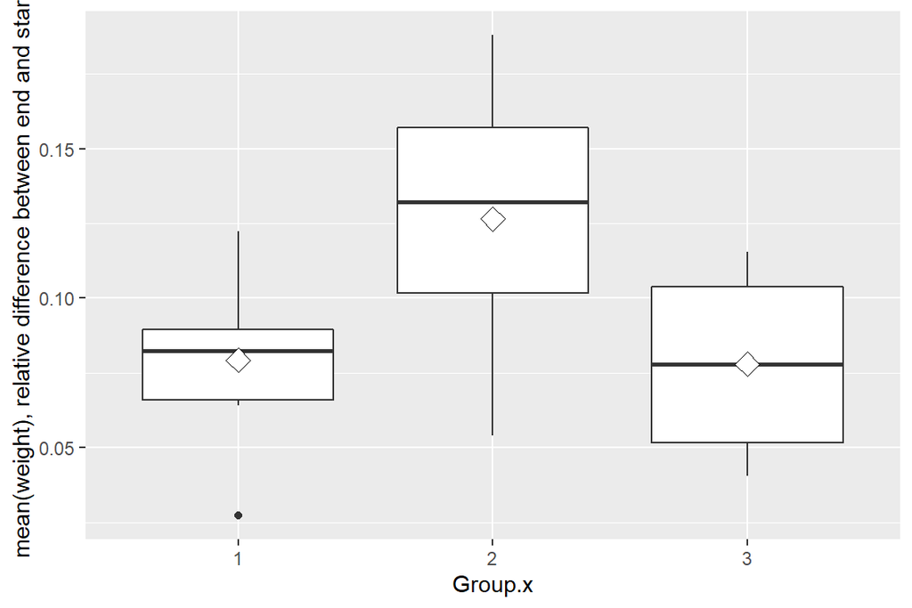

```r
library(dplyr)
library(tidyr)

# Calculate the relative change
RATSLS_change<-mutate(RATSLS_change,relative_difference=difference/mean.x)

# Draw a boxplot of the difference in means at the end and at the start by treatment
library(ggplot2)
ggplot(RATSLS_change, aes(x = Group.x, y = relative_difference)) +
  geom_boxplot() +
  stat_summary(fun = "mean", geom = "point", shape=23, size=4, fill = "white") +
  scale_y_continuous(name = "mean(weight), relative difference between end and start")
```

```r
sd_RATSLS<-RATSLS %>% group_by(Group) %>%
  summarise( sd=sd(mean) ) %>%
  ungroup()
```

We will also follow the exercise in primarily using the overall group-wise means in our testing, instead the differences or the relative differences. We will, however, also look at the differences after conditioning on the baseline weights, which mimics testing the null of no difference with the difference in means as the primary outcome.

We start by looking at the two-sample t-test, with comparisons between the means of groups 1 against 2, 1 against 3, and 2 against 3. We have a two-sided test with our null hypothesis that the mean weights of the individual rats measured during the followup come from the same distribution with equal mean (and assuming equal variance). We should be wary that given that our sample variances differ, and that we have a tiny sample altogether, the assumption of approximate normality of the sampling distributions of the group-wise means inherent in the t-test might not hold.

```r
# Perform a two-sample t-test, group 1 against 2
t.test(mean ~ Group, data = RATSLS[1:12,], var.equal = TRUE)
```

```
##
##  Two Sample t-test
##
## data:  mean by Group
## t = -9.0646, df = 10, p-value = 3.88e-06
## alternative hypothesis: true difference in means between group 1 and group 2 is not equal to 0
## 95 percent confidence interval:
##  -277.5345 -168.0155
## sample estimates:
## mean in group 1 mean in group 2
##         265.025         487.800
```

```r
# Perform a two-sample t-test, group 1 against 3
t.test(mean ~ Group, data = RATSLS[-(9:12),], var.equal = TRUE)
```

```
##
##  Two Sample t-test
##
## data:  mean by Group
## t = -27.824, df = 10, p-value = 8.345e-11
## alternative hypothesis: true difference in means between group 1 and group 3 is not equal to 0
## 95 percent confidence interval:
##  -283.4943 -241.4557
## sample estimates:
## mean in group 1 mean in group 3
##         265.025         527.500
```

```r
# Perform a two-sample t-test, group 2 against 3
t.test(mean ~ Group, data = RATSLS[9:16,], var.equal = TRUE)
```

```
##
##  Two Sample t-test
##
## data:  mean by Group
## t = -1.0686, df = 6, p-value = 0.3263
## alternative hypothesis: true difference in means between group 2 and group 3 is not equal to 0
## 95 percent confidence interval:
##  -130.60428   51.20428
## sample estimates:
## mean in group 2 mean in group 3
##           487.8           527.5
```

The result of the t-test is that the data is compatible with the null of equal means (assuming equal variances) when comparing groups two and three, but highly incompatible when making the other two comparisons. The t-value for the test between groups 1 and 2 is roughly -9, with 10 degrees of freedom and a p-value of $0.000004$. The t-value for the test between groups 1 and 3 is roughly -28, with 10 degrees of freedom and a p-value of $0.00000000008$.

Just for the fun of it, let us see the results when using the differences in the means as the primary outcome.

```r
# Perform a two-sample t-test, group 1 against 2
t.test(difference ~ Group.x, data = RATSLS_change[1:12,], var.equal = TRUE)
```

```
##
##  Two Sample t-test
##
## data:  difference by Group.x
## t = -4.3797, df = 10, p-value = 0.001378
## alternative hypothesis: true difference in means between group 1 and group 2 is not equal to 0
## 95 percent confidence interval:
##  -55.91789 -18.20711
## sample estimates:
## mean in group 1 mean in group 2
##         19.8125         56.8750
```

```r
# Perform a two-sample t-test, group 1 against 3
t.test(difference ~ Group.x, data = RATSLS_change[-(9:12),], var.equal = TRUE)
```

```
##
##  Two Sample t-test
##
## data:  difference by Group.x
## t = -2.98, df = 10, p-value = 0.01381
## alternative hypothesis: true difference in means between group 1 and group 3 is not equal to 0
## 95 percent confidence interval:
##  -33.315338  -4.809662
## sample estimates:
## mean in group 1 mean in group 3
##         19.8125         38.8750
```

```r
# Perform a two-sample t-test, group 2 against 3
t.test(difference ~ Group.x, data = RATSLS_change[9:16,], var.equal = TRUE)
```

```
##
##  Two Sample t-test
##
## data:  difference by Group.x
## t = 1.2811, df = 6, p-value = 0.2474
## alternative hypothesis: true difference in means between group 2 and group 3 is not equal to 0
## 95 percent confidence interval:
##  -16.37944  52.37944
## sample estimates:
## mean in group 2 mean in group 3
##          56.875          38.875
```

The data is highly incompatible with the null of equal differences between groups 1 and 2, incompatible with the null between groups 1 and 3, and compatible with the null between groups 2 and 3.

We should like to note in the passing that testing a point null hypothesis is somewhat silly altogether: with a continuous outcome measure, with support on the positive reals, the *a priori* probability of the null of equal means being true is 0. This implies we are testing a null we know to be untrue analytically even before collecting or observing any data! Thus, with a large enough sample size (yet holding other characteristics of our sampling scheme constant), we would eventually be guaranteed a sample statistic that is incompatible with our null. This suggests that when carrying out such significance (or hypothesis testing, where there exists an alternative hypothesis) with a point null, we ought not be interpreted as testing the truth of any hypothesis we have seriously ever entertained at all, but merely conducting some sort of preliminary check on the size of our effect of potential interest: if it does not even pass the meager bar of statistical (non-nil) significance, then we might rest rather assured that the effect is neither sizeable enough to be of much substantive interest (yet there are issues with even such use of the procedure).

A much more meaningful framework would be to calculate the posterior of the difference of the two means, which would not only help us escape triviality, but also allow us a probability interpretation for any dichotomous hypothesis we’d like to postulate, including the probability of the difference being larger than or smaller than 0.

If we nonetheless stuck with classical testing procedures, we could make the comparisons between the three groups simultaneously with analysis of variance (ANOVA) and its accompanying F-test, as follows (after having gained the results in the above, this does not bring much additional information, though, since we are sure to reject the null of the equality of all group-wise means given that we have already done so for some of the pairwise means).

```r
library(dplyr)
library(tidyr)

# Fit the linear model with the mean as the response
fit <- lm(mean ~ Group, data = RATSLS)

# Compute the analysis of variance table for the fitted model with anova()
anova(fit)
```

```
## Analysis of Variance Table
##
## Response: mean
##           Df Sum Sq Mean Sq F value    Pr(>F)
## Group      2 238620  119310  88.525 2.679e-08 ***
## Residuals 13  17521    1348
## ---
## Signif. codes:  0 '***' 0.001 '**' 0.01 '*' 0.05 '.' 0.1 ' ' 1
```

We get an F-statistic of roughly 88 with two degrees of freedom, implying a very low p-value, as expected.

We get results also highly incompatible with the null if we conduct the test by conditioning on the baseline, or by using our difference in means as the primary outcome.

```r
library(dplyr)
library(tidyr)

# We have the datasets sorted in a way which allows us simply to take the first 16 observations of weighs as providing the baseline weight for IDs 1 to 16 on the first 16 rows f the RATSLS data.frame.
RATSLS$baseline<-as.vector(as.matrix(RATSL[1:16,4]))

# Fit the linear model with the mean as the response and the baseline as a conditioning variable
fit <- lm(mean ~ Group + baseline, data = RATSLS)

# Compute the analysis of variance table for the fitted model with anova()
anova(fit)
```

```
## Analysis of Variance Table
##
## Response: mean
##           Df Sum Sq Mean Sq F value    Pr(>F)
## Group      2 238620  119310  874.89 9.986e-14 ***
## baseline   1  15884   15884  116.48 1.562e-07 ***
## Residuals 12   1636     136
## ---
## Signif. codes:  0 '***' 0.001 '**' 0.01 '*' 0.05 '.' 0.1 ' ' 1
```

When conditioning on the baseline, we notice that both the baseline and the group are highly statistically significant – as we have already stressed, the data is highly incompatible with both the null that the weights at baseline would be equal between the groups, and also that the group means would be equal, even after accounting for the differences in the baseline weights. We may observe that this incompatibility holds if we tested the slightly different null of the equality of the means of the differences (of means).

```r
library(dplyr)
library(tidyr)


# Fit the linear model with the mean as the response and the baseline as a conditioning variable
fit <- lm(difference ~ Group.x, data = RATSLS_change)

# Compute the analysis of variance table for the fitted model with anova()
anova(fit)
```

```
## Analysis of Variance Table
##
## Response: difference
##           Df Sum Sq Mean Sq F value   Pr(>F)
## Group.x    2 3798.0 1899.01   9.195 0.003247 **
## Residuals 13 2684.8  206.53
## ---
## Signif. codes:  0 '***' 0.001 '**' 0.01 '*' 0.05 '.' 0.1 ' ' 1
```